# Part I - (Data Science Job Salaries Dataset)

## by (Kudakwashe Tsikaurere)

## Introduction

This dataset is a Kaggle Dataset [Data Science Job salaries](https://www.kaggle.com/datasets/ruchi798/data-science-job-salaries). Its a popular dataset on Kaggle which we are going to explore and get meaningful visualizations.

## Preliminary Wrangling

```python
# import all packages and set plots to be embedded inline
import numpy as np
import pandas as pd
import matplotlib.pyplot as plt
import seaborn as sb
import requests
from bs4 import BeautifulSoup, SoupStrainer
from glob import glob
import wget
import urllib.request
import httplib2
%matplotlib inline
```

# Data Gathering

```python
#Load kaggle API From local drive
from kaggle.api.kaggle_api_extended import KaggleApi
api = KaggleApi()
api.authenticate()
```

```python
#downloading dataset for Data science jobs
!kaggle datasets download -d ruchi798/data-science-job-salaries
```

```
data-science-job-salaries.zip: Skipping, found more recently modified local copy (use --force to force download)
```

```python
#Extract the downloaded zipfile
from zipfile import ZipFile
zf = ZipFile('data-science-job-salaries.zip')
#extracted data is saved in the same directory as notebook
zf.extractall()
zf.close()
```

```python
#check current working directory and read the csv file
import os
print(os.getcwd())
df = pd.read_csv('ds_salaries.csv',index_col=False)
```

```
C:\Users\ADMIN\Desktop\Data Visualization\Visualization Project\Project Template
```

```python
#Look at the dataset
df.head()
```

|  | Unnamed: 0 | work_year | experience_level | employment_type | job_title | salary | salary_currency | salary_in_usd | employee_residence | remote_ratio | company_location | company_size |
| --- | --- | --- | --- | --- | --- | --- | --- | --- | --- | --- | --- | --- |
| 0 | 0 | 2020 | MI | FT | Data Scientist | 70000 | EUR | 79833 | DE | 0 | DE | L |
| 1 | 1 | 2020 | SE | FT | Machine Learning Scientist | 260000 | USD | 260000 | JP | 0 | JP | S |
| 2 | 2 | 2020 | SE | FT | Big Data Engineer | 85000 | GBP | 109024 | GB | 50 | GB | M |
| 3 | 3 | 2020 | MI | FT | Product Data Analyst | 20000 | USD | 20000 | HN | 0 | HN | S |
| 4 | 4 | 2020 | SE | FT | Machine Learning Engineer | 150000 | USD | 150000 | US | 50 | US | L |

```python
#check column names
df.columns
```

```
Index(['Unnamed: 0', 'work_year', 'experience_level', 'employment_type',
       'job_title', 'salary', 'salary_currency', 'salary_in_usd',
       'employee_residence', 'remote_ratio', 'company_location',
       'company_size'],
      dtype='object')
```

```python
#Remove unnamed column
df = df.iloc[: , 1:]
```

```python
df.head()
```

|  | work_year | experience_level | employment_type | job_title | salary | salary_currency | salary_in_usd | employee_residence | remote_ratio | company_location | company_size |
| --- | --- | --- | --- | --- | --- | --- | --- | --- | --- | --- | --- |
| 0 | 2020 | MI | FT | Data Scientist | 70000 | EUR | 79833 | DE | 0 | DE | L |
| 1 | 2020 | SE | FT | Machine Learning Scientist | 260000 | USD | 260000 | JP | 0 | JP | S |
| 2 | 2020 | SE | FT | Big Data Engineer | 85000 | GBP | 109024 | GB | 50 | GB | M |
| 3 | 2020 | MI | FT | Product Data Analyst | 20000 | USD | 20000 | HN | 0 | HN | S |
| 4 | 2020 | SE | FT | Machine Learning Engineer | 150000 | USD | 150000 | US | 50 | US | L |

```python
#check structure of dataset
df.shape
```

```
(607, 11)
```

```python
#check dtypes
df.info()
```

```
<class 'pandas.core.frame.DataFrame'>
RangeIndex: 607 entries, 0 to 606
Data columns (total 11 columns):
 #   Column              Non-Null Count  Dtype
---  ------              --------------  -----
 0   work_year           607 non-null    int64
 1   experience_level    607 non-null    object
 2   employment_type     607 non-null    object
 3   job_title           607 non-null    object
 4   salary              607 non-null    int64
 5   salary_currency     607 non-null    object
 6   salary_in_usd       607 non-null    int64
 7   employee_residence  607 non-null    object
 8   remote_ratio        607 non-null    int64
 9   company_location    607 non-null    object
 10  company_size        607 non-null    object
dtypes: int64(4), object(7)
memory usage: 52.3+ KB
```

```python
#Convert to necessary dTypes for analysis
df.work_year.astype('int32')
df['work_year'] = pd.to_datetime(df.work_year, format = '%Y')
df['salary']  =  df['salary'].astype('float')
df['salary_in_usd']  =  df['salary_in_usd'].astype('float')
```

```python
#Change multiple columns to correct dtye
for col in ['experience_level', 'employment_type', 'company_size',]:
    df[col] = df[col].astype('category')
```

```python
#Change multiple columns to correct dtye
for col in ['job_title', 'company_location', 'employee_residence','salary_currency']:
    df[col] = df[col].astype('string')
```

```python
#check new dtypes
df.info()
```

```
<class 'pandas.core.frame.DataFrame'>
RangeIndex: 607 entries, 0 to 606
Data columns (total 11 columns):
 #   Column              Non-Null Count  Dtype
---  ------              --------------  -----
 0   work_year           607 non-null    datetime64[ns]
 1   experience_level    607 non-null    category
 2   employment_type     607 non-null    category
 3   job_title           607 non-null    string
 4   salary              607 non-null    float64
 5   salary_currency     607 non-null    string
 6   salary_in_usd       607 non-null    float64
 7   employee_residence  607 non-null    string
 8   remote_ratio        607 non-null    int64
 9   company_location    607 non-null    string
 10  company_size        607 non-null    category
dtypes: category(3), datetime64[ns](1), float64(2), int64(1), string(4)
memory usage: 40.4 KB
```

```python
#statistical summary of dataset
df.describe()
```

|  | salary | salary_in_usd | remote_ratio |
| --- | --- | --- | --- |
| count | 6.070000e+02 | 607.000000 | 607.00000 |
| mean | 3.240001e+05 | 112297.869852 | 70.92257 |
| std | 1.544357e+06 | 70957.259411 | 40.70913 |
| min | 4.000000e+03 | 2859.000000 | 0.00000 |
| 25% | 7.000000e+04 | 62726.000000 | 50.00000 |
| 50% | 1.150000e+05 | 101570.000000 | 100.00000 |
| 75% | 1.650000e+05 | 150000.000000 | 100.00000 |
| max | 3.040000e+07 | 600000.000000 | 100.00000 |

### What is the structure of your dataset?

The dataset contains 607 records and 11 Features because its a trending dataset from kaggle it appears to be clean. A few numeric columns and most being categorical as well as string and date variables. Even though the dataset is small , but for the purpse of this project we want to focus on visualizations and analysis.

### What is/are the main feature(s) of interest in your dataset?

The salary feature of course are the main focus closely associated with the , job_title. We would like to know the top 10 or 20 jobs based on salary alone but also based on other condintion like experience , employment type ,remote ration etc

### What features in the dataset do you think will help support your investigation into your feature(s) of interest?

The following feature [work_year , experience_level,employment type, remote_ratio, company size] will have a very interesting effect on the main feature of our dataset and I am going to investigate using multiple types of visualization the relationship between these variable

## Univariate Exploration

Here I will be exploring each feature individually to get a feel of the dataset and how its spread in the columns

#### Question 1

What is the frequency distribution in the work experience column?Its a qualitative variable(categorical) so I prefer to use a bar chat

#### Code and Visualization

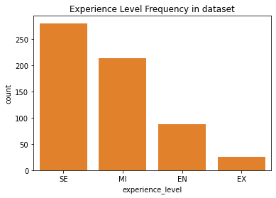

```python
base_color = sb.color_palette()[1]

freq = df['experience_level'].value_counts().index


# Plot the bar chart in the decreasing order of the frequency experience level`
sb.countplot(data=df, x='experience_level', color=base_color, order=freq)
plt.title("Experience Level Frequency in dataset")
```

#### Insights

Most jobs are of Senior level experienece and the least is being te executive/Expert level. Meaning most of the jobs were not for expert/executive positions

```python
### Create Function for poltiing bar charts
def plotbarchat(dfcolumn,dataframe,column,colorx,title):
                   base_color = sb.color_palette()[colorx]
                   freq = dfcolumn.value_counts().index
                   sb.countplot(data=dataframe, x=f"{column}", color=base_color, order=freq)
                   plt.title(f"{title}")
```

#### Question 2

Which country had the most job entries in this dataset?

#### Code and Visualization

```
(0.0, 10.0)
```

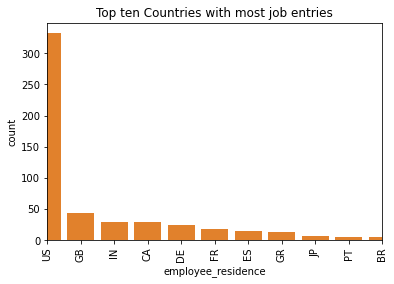

```python
plotbarchat(df['employee_residence'],df,"employee_residence",1,"Top ten Countries with most job entries")
plt.xticks(rotation=90)
plt.xlim((0,10))
```

#### Insights

above 50% of the entire dataset of job entries are from the US, with the second largest being Great Britain just below 50 as well as every other country. This just the 10 top ten countries with most entries

#### Question 3

Which employment type is the most frequent?

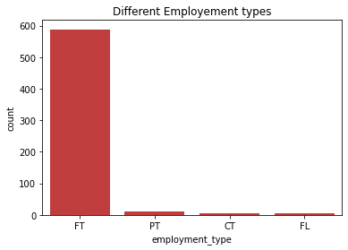

```python
plotbarchat(df['employment_type'],df,"employment_type",3,"Different Employement types")
```

#### Insights

Almost all job entries are of full time employement and the other employment types are well below the 100 job entries threshold in the dataset

#### Question 4

What is salary distribution before being converted to usd?

#### Code and Visualize

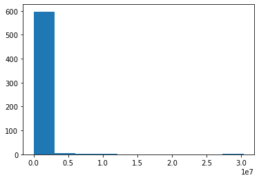

```python
plt.hist(data = df, x = 'salary');
```

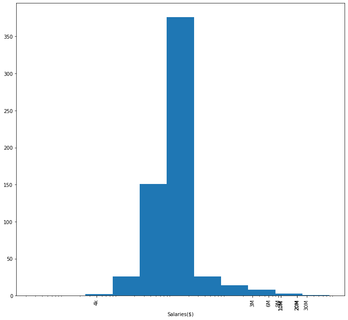

```python
#Since we are working with millions and thousands the log binsize is needed
log_binsize = 0.5
bins = 10 ** np.arange(2.4, np.log10(df['salary'].max())+log_binsize, log_binsize)

plt.figure(figsize=[12, 11])
plt.hist(data = df, x = 'salary', bins = bins)
plt.xscale('log')
plt.xticks([4e3, 3e6, 6e6, 9e6, 1e7,1.e7, 1.e7, 2e7, 2e7, 2e7, 3e7], ['4k', '3M', '6M', '9M', '10M', '10M','10M','20M', '20M', '20M', '30M'],rotation =90)
plt.xlabel('Salaries($)')
plt.show()
```

#### Insights

According to the data almost of the salaries with their different currencies fall between 4k and 3M.The data skews to the right and we have a few outlier millions 20m or 30m recorded

#### Question 5

How is the salary(in usd) distributed?

#### Code and Viz

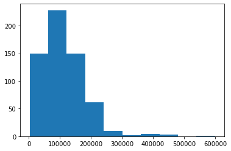

```python
plt.hist(data=df,x='salary_in_usd')
```

### Discuss the distribution(s) of your variable(s) of interest. Were there any unusual points? Did you need to perform any transformations?

I used log scale for the salary column which is made up of different salaries from different countries with their own inflation rate. I did not expect both salary and salary in usd columns to have be skewed to the right as there is great difference in terms of the value of those salaries. Its as if they maintained their skewness even though the salary was converted to one currency.

### Of the features you investigated, were there any unusual distributions? Did you perform any operations on the data to tidy, adjust, or change the form of the data? If so, why did you do this?

**No Tidying done on this dataset** Just removal of an unnamed column.

## Bivariate Exploration

In this part we'l be exploring casual and relationship between our main variable and the other variables variables

#### Question 1 Has the average salary increased or decreased ?

#### Code and Visualization

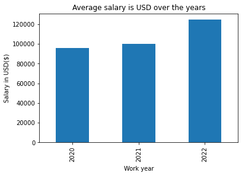

```python
df.groupby(df['work_year'].dt.year)['salary_in_usd'].mean().plot(kind='bar');
plt.title("Average salary is USD over the years");
plt.xlabel("Work year", labelpad=7)
plt.ylabel("Salary in USD($)");
```

#### Insight

The average salary increased has increased from 2020 to 2022 a gradual increase

#### Question 2

What is the maximum salary for each Job title in USD?

#### Code and Visualization

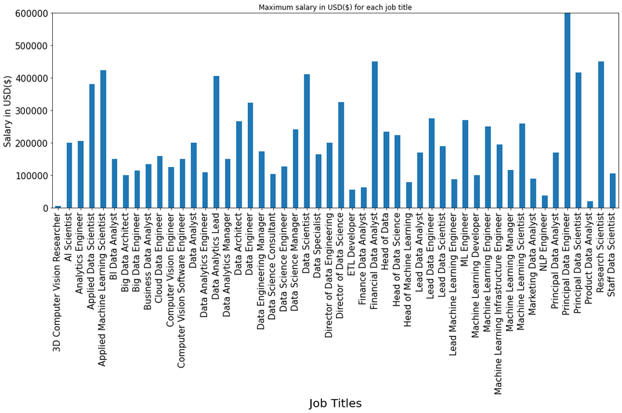

```python
df.groupby(['job_title'])['salary_in_usd'].max().plot(kind='bar')
plt.title("Maximum salary in USD($) for each job title")
plt.rcParams["figure.figsize"] = (15,10)
plt.rcParams["figure.autolayout"] = True
plt.margins(x=0, y=0)
plt.xlabel("Job Titles", labelpad=7,fontsize=20)
plt.ylabel("Salary in USD($)",fontsize=15)
plt.xticks(fontsize=15)
plt.yticks(fontsize=15)
plt.show()
```

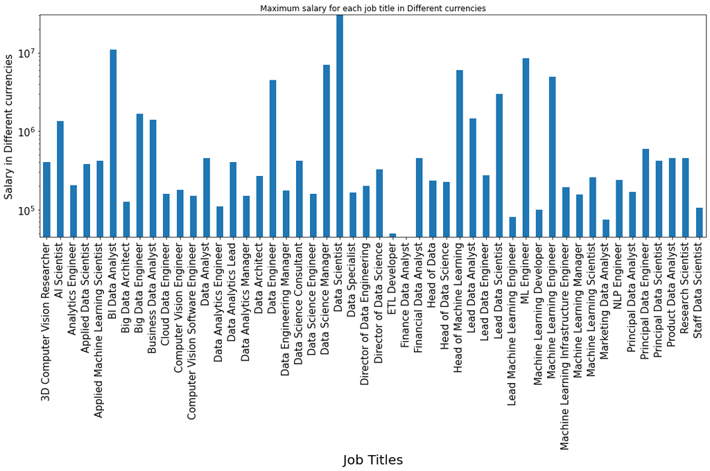

```python
log_binsize = 0.5
df.groupby(['job_title'])['salary'].max().plot(kind='bar')
plt.yscale('log')
plt.title("Maximum salary for each job title in Different currencies")
plt.rcParams["figure.figsize"] = (15,10)
plt.rcParams["figure.autolayout"] = True
plt.margins(x=0, y=0)
plt.xlabel("Job Titles", labelpad=7,fontsize=20)
plt.ylabel("Salary in Different currencies",fontsize=15)
plt.xticks(fontsize=15)
plt.yticks(fontsize=15)
plt.show()
```

#### Question 3

What is the relationship between the salart in usd and the salary in all other currencies?

#### Code and Visualization

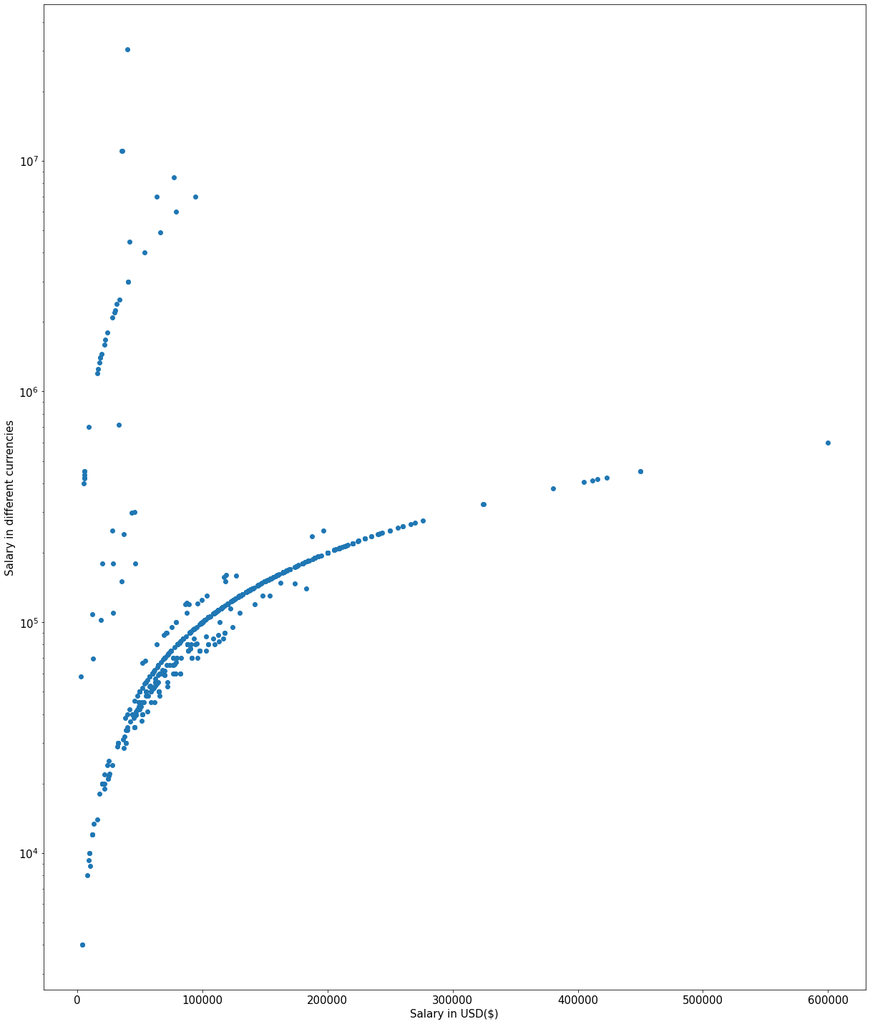

```python
plt.scatter(data = df, x = 'salary_in_usd', y = 'salary')
plt.xlabel('Salary in USD($)',fontsize=15)
plt.ylabel('Salary in different currencies',fontsize=15)
plt.yscale('log');
plt.xticks(fontsize=15)
plt.yticks(fontsize=15);
```

#### Insight

The data clearly shows that there's correlation between salary in different currency and salary in usd until a certain figure.There a lot of outliers as well.

#### Question 4

What is average salaries of each type of company size?

#### Code and Visualize

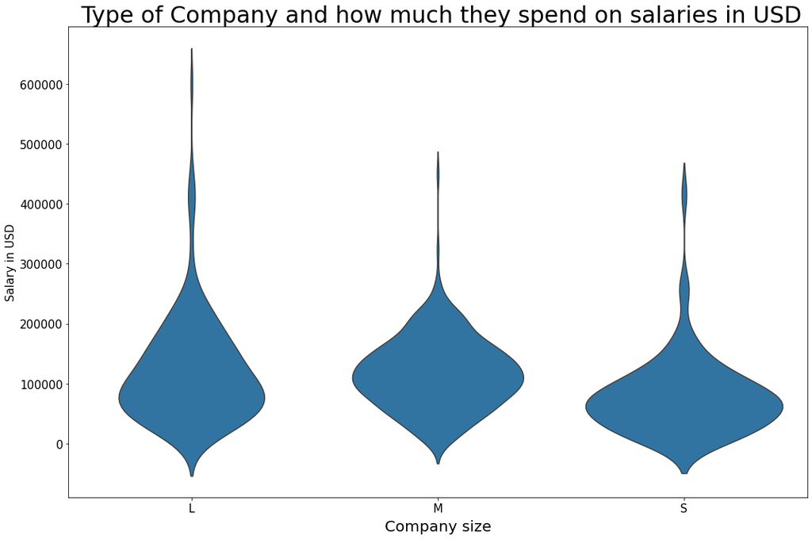

```python
base_color = sb.color_palette()[0]
sb.violinplot(data=df, x='company_size', y='salary_in_usd', color=base_color, inner=None)
plt.xticks(fontsize=15)
plt.yticks(fontsize=15);
plt.title(" Type of Company and how much they spend on salaries in USD",fontsize=30)
plt.xlabel("Company size", labelpad=7,fontsize=20)
plt.ylabel("Salary in USD",fontsize=15)
```

#### Question 5

Are most jobs remote , hybrid or full time office?

#### Code and Visualize

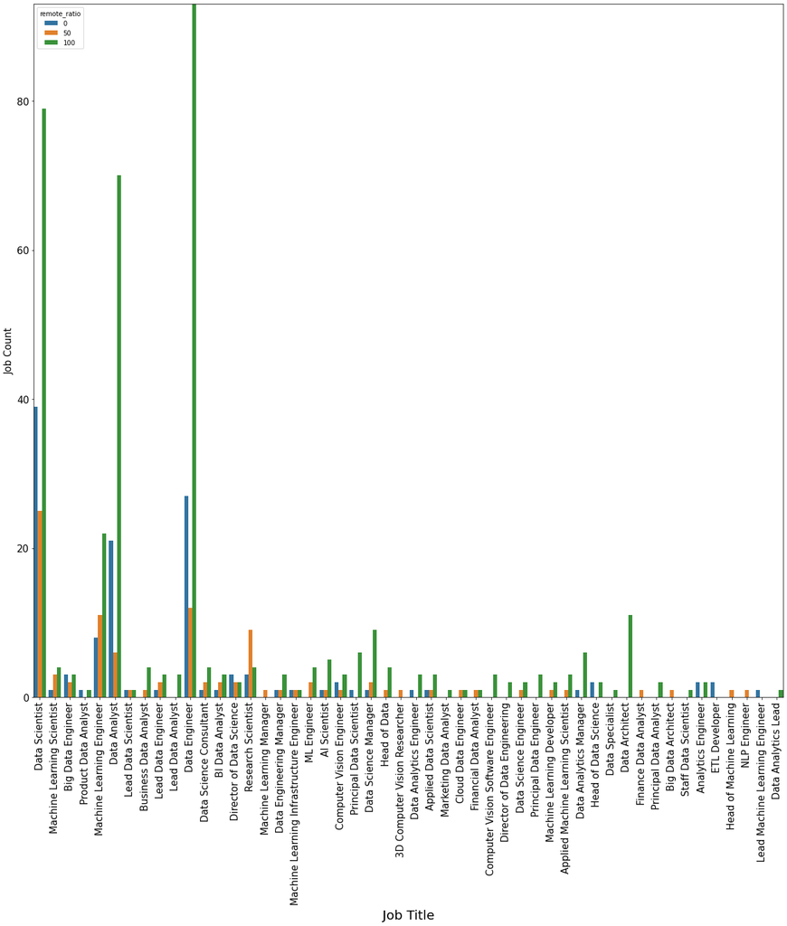

```python
sb.countplot(data=df,x='job_title',hue='remote_ratio')
plt.rcParams["figure.figsize"] = (17,20)
plt.rcParams["figure.autolayout"] = True
plt.margins(x=0, y=0)
plt.title("Remote status of jobs",fontsize=20)
plt.ylabel("Job Count",fontsize=15)
plt.xlabel("Job Title")
plt.xticks(fontsize=15)
plt.xticks(rotation=90)
plt.yticks(fontsize=15)
plt.show()
```

#### Insight

Most job title that feature in the dataset are 100% remote , with some being 50% remote

### Talk about some of the relationships you observed in this part of the investigation. How did the feature(s) of interest vary with other features in the dataset?

Well the salary in usd and the actual salary have a very interesting correlation as they only correlated until a certain figure and then they were multiple outliers in the extremes for salary in different usd

### Did you observe any interesting relationships between the other features (not the main feature(s) of interest)?

Ploting the maximum salary in usd and salary in other currencies showed very signficant difference. Infact the job titles which had high maximum salaries in salary usd were different than those in salary with different currencies

## Multivariate Exploration

#### Question 1

which employemnt type earns the most throughout the years?

#### Code and Visualize

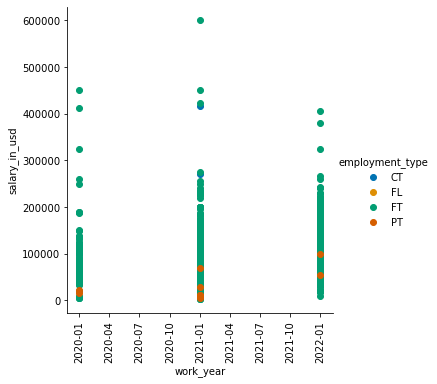

```python
g = sb.FacetGrid(data = df, hue = 'employment_type', height = 5,
                 palette = 'colorblind');
g.map(plt.scatter, 'work_year', 'salary_in_usd');
g.add_legend();
plt.xticks(rotation=90);
```

#### Insight

Most jobs that pay well are full time jobs with a few part jobs at the bottom

#### Code and Visualize

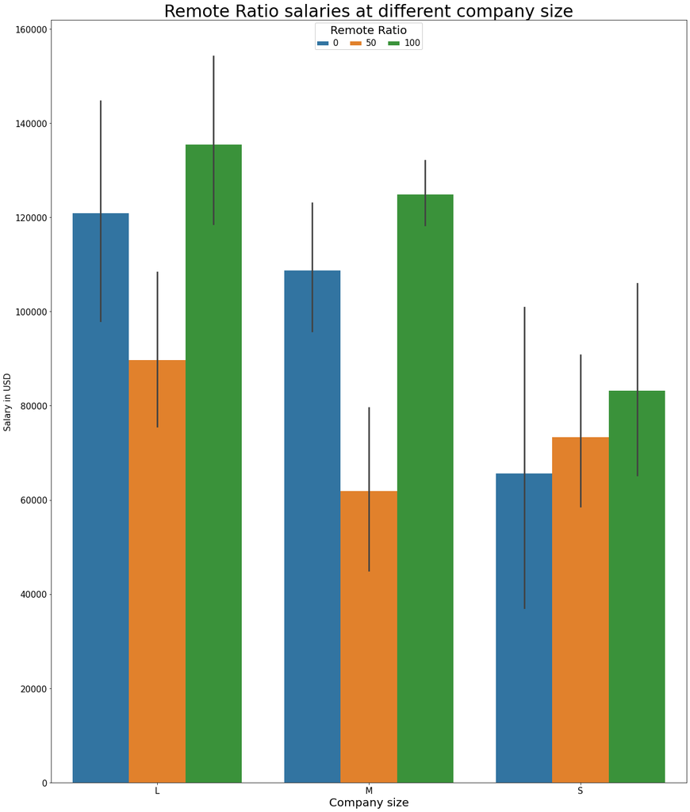

```python
ax = sb.barplot(data = df, x = 'company_size', y = 'salary_in_usd',
                hue = 'remote_ratio')
ax.legend(loc='upper center', ncol = 3, framealpha = 1, title = 'Remote Ratio')
ax.set_title("Remote Ratio salaries at different company size",fontsize=30)
plt.setp(ax.get_legend().get_texts(), fontsize='15') # for legend text
plt.setp(ax.get_legend().get_title(), fontsize='20')
plt.xticks(fontsize=15)
plt.yticks(fontsize=15)
plt.xlabel("Company size", fontsize=20)
plt.ylabel("Salary in USD",fontsize=15);
```

#### Insight

The Large companies have the highest paid remote workes , followed by medium followed by small companies. For 50% Remote The large companies have the highest followed by the small companies

#### Question

What is salary for each experience every level throughout the years?

#### Code and Visualize

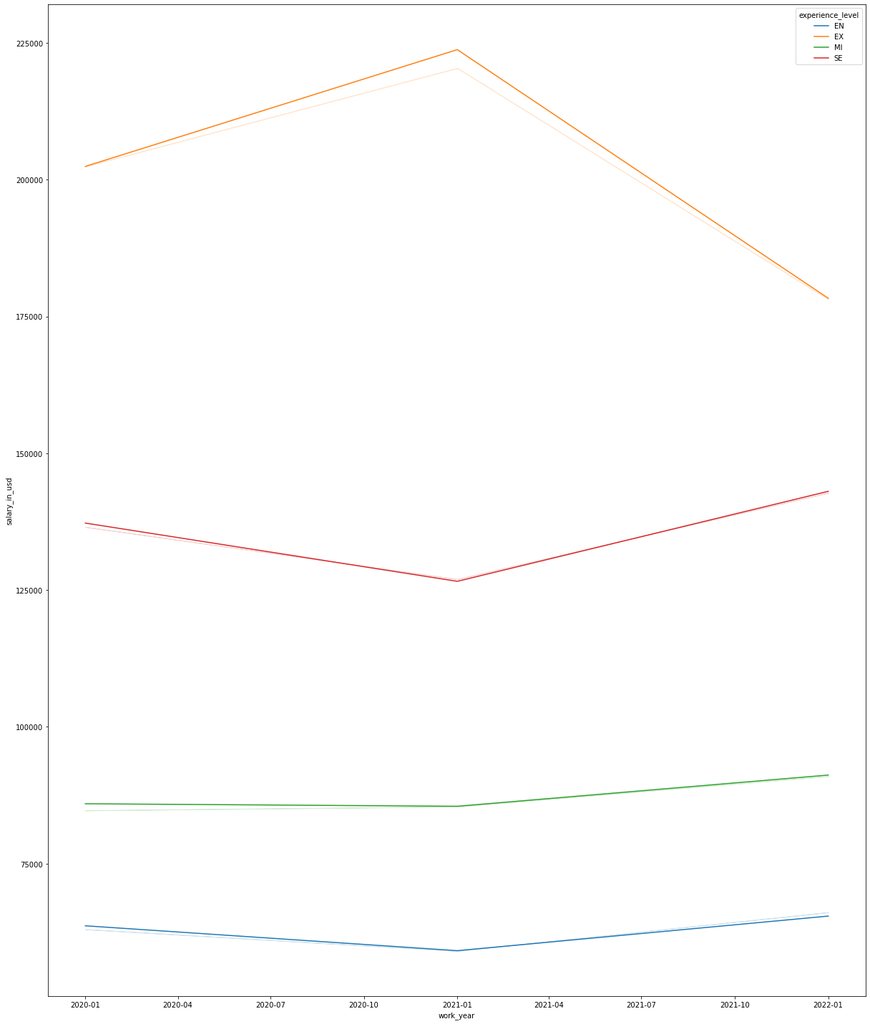

```python
sb.lineplot(x="work_year", y="salary_in_usd",hue="experience_level" ,
    markers=True,dashes=False,ci=0,data=df)
```

#### Insight

The executive position clearly make the most money while the seniors follows, Middle being third and entry is at the lowest as expectd. All graphs indicate a change in 2021.

### Talk about some of the relationships you observed in this part of the investigation. Were there features that strengthened each other in terms of looking at your feature(s) of interest?

The relationship I was interested in was between the time series between salary and the experience level. This indicates a broad idea of what the data science industry is like in terms of salaries with varying experience levels

### Were there any interesting or surprising interactions between features?

I was suprised that almost all the companies regardless of size have adapted a a remote working environment and that those remote employees are the most paid than those who stay in the office

## Conclusions

Most job title that feature in the dataset are 100% remote , with some being 50% remote.Most jobs that pay well are full time jobs with a few part jobs at the bottom. The Large companies have the highest paid remote workers , followed by medium followed by small companies. For the 50 Remote ratio mark, The large companies have the highest followed by the small companies.The executive position clearly make the most money while the seniors follows, Middle being third and entry is at the lowest as expectd. All graphs indicate a change in 2021. All the levels were affected and showed a decrease in 2021 except the executive experience level. It showed an increase in 2021